# Homework2

## Problem 3

### Plot 1

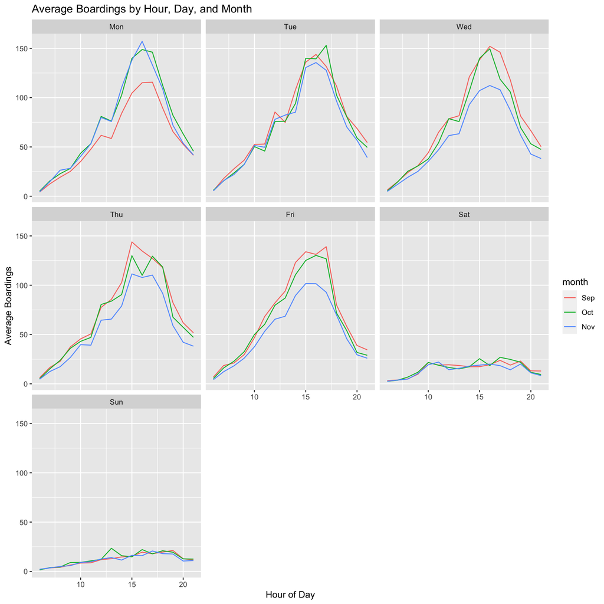

The plots above display the average boardings of the bus separated into 7 plots for each day of the week while also showing the numbers for each month. The plots look the same for the most part from Monday through Friday as you can see when people are going to and from campus. The weekends have a steady amount of boardings on the bus and this number is very low as a lot of people are going to places on weekends. However there is a strange occurrence in the data as on Mondays in September there is a decrease in boardings. This is likely due to Labor Day as people aren’t going to campus on one of the four Monday’s of the month which brings the average down compared to the rest of the months. Similarly on Wednesday, Thursday, and Friday for the month of November there is a slight decrease in boardings. This is likely due to Thanksgiving as people were not going to campus for one of the four Wednesday, Thursday, and Friday’s in the month. For the rest of the week days the hours of peak boarding is the same at around 4 or 5 pm where most of the people are coming back home from campus. This number changes on weekends as there is no real peak with mostly flat lines on the graphs. This is due to the facts that people have different schedules on weekends.

### Plot 2

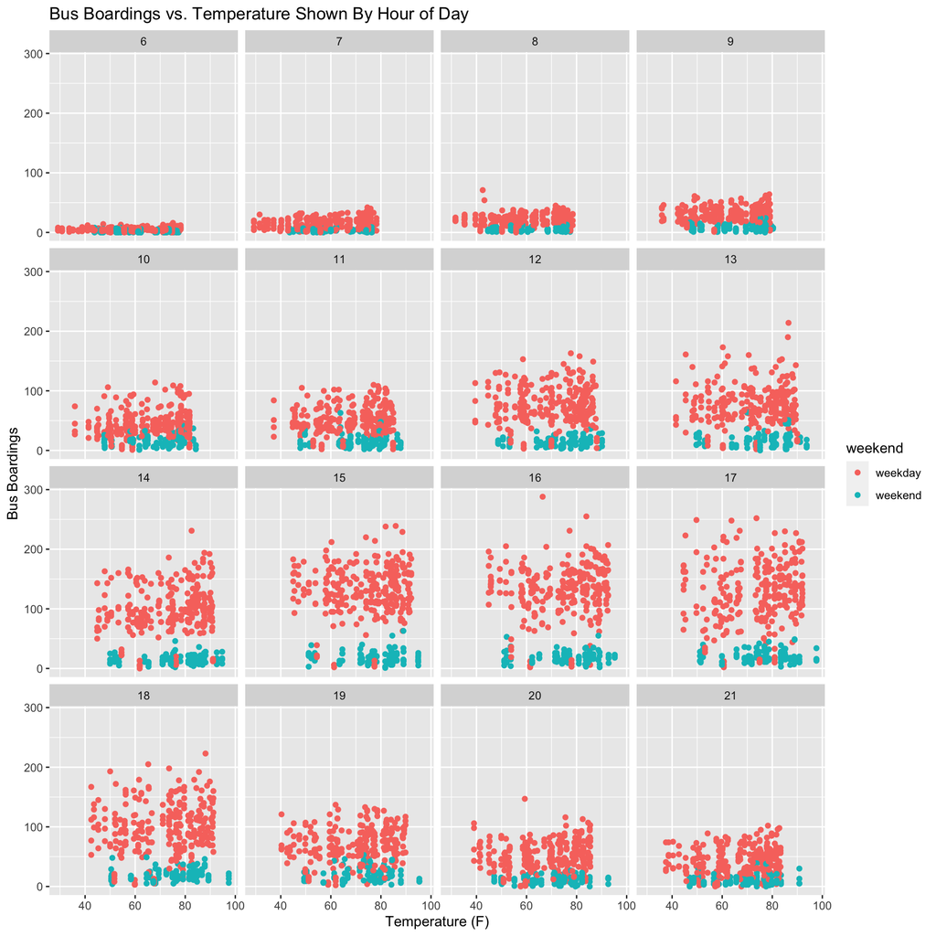

The plots above show the relationship between temperature outside and the number of boardings on the bus seperated by the hour of the day. There seems to be more boardings at certain times in the day especially from 12 - 6 pm. Also as mentioned in the previous plot there appear to be significantly more boardings on weekdays than weekends. The graphs show that there is no real relationship between temperature and boardings as all the graphs look like a rectangle implying that the boardings look the same regardless of outside temperature.

## Problem 4

### Part A

| Performer | Song | Count |
| --- | --- | --- |
| Imagine Dragons | Radioactive | 87 |
| AWOLNATION | Sail | 79 |
| Jason Mraz | I’m Yours | 76 |
| The Weeknd | Blinding Lights | 76 |
| LeAnn Rimes | How Do I Live | 69 |
| LMFAO Featuring Lauren Bennett & GoonRock | Party Rock Anthem | 68 |
| OneRepublic | Counting Stars | 68 |
| Adele | Rolling In The Deep | 65 |
| Jewel | Foolish Games/You Were Meant For Me | 65 |
| Carrie Underwood | Before He Cheats | 64 |

The table shows the top 10 songs that appeared on the Billboard Top 100 since 1958 and this was calculated based on the most weeks spent on the Billboard Top 100. There are three columns in the table; performer name, song name, and the number of weeks on in the top 100. We can see the top song is Radioactive by Imagine Dragons wtih 87 weeks in the Top 100.

### Part B

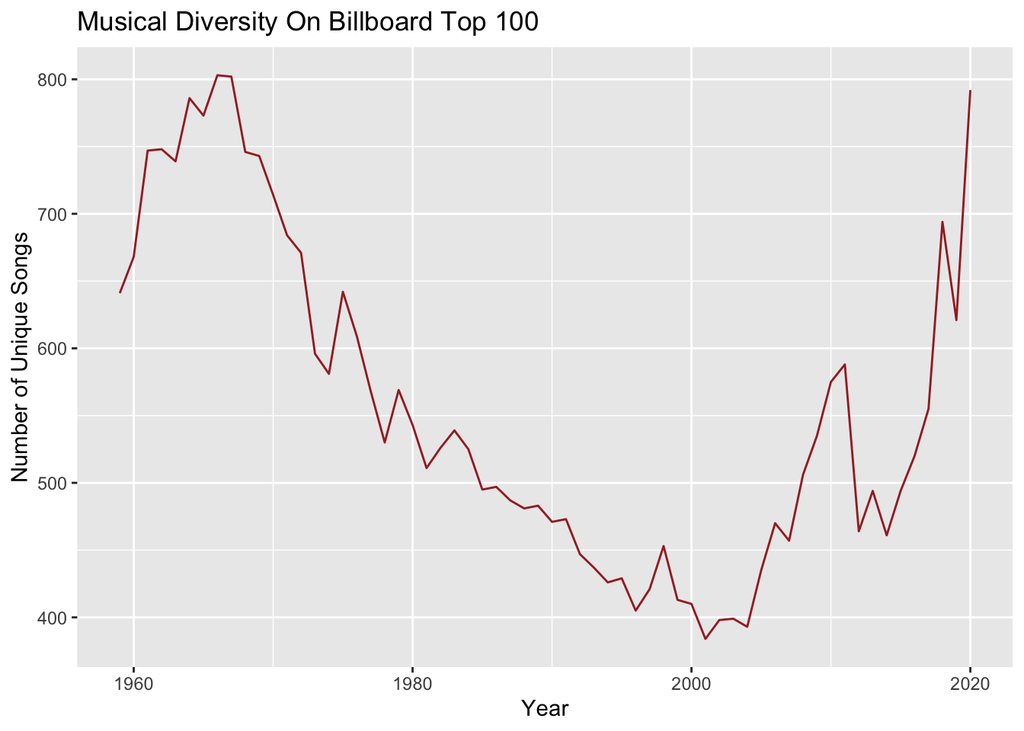

### Part C

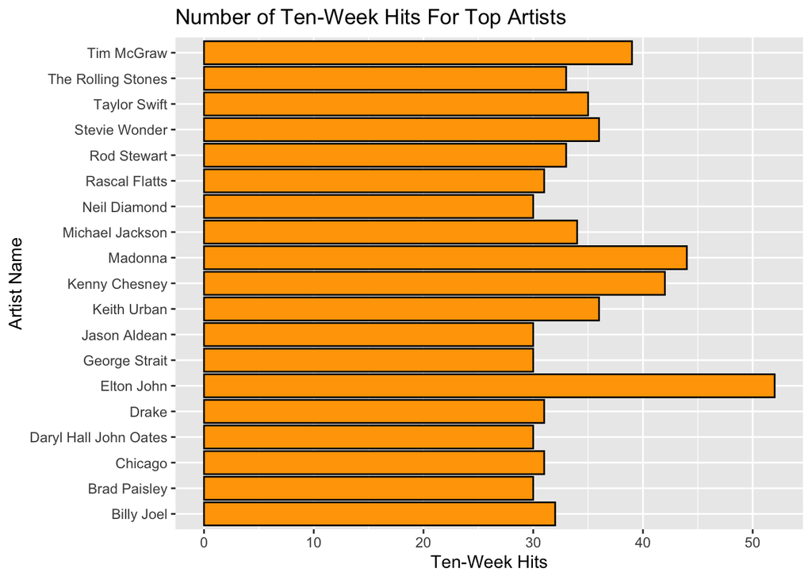

This bar plot shows the artists who have had 30 different songs that have been in the Billboard Top 100 for over 10 weeks and the plot shows exactly how many of these songs each artist has had. There are a total of 19 artists who have achieved this feat and the artist with the most hit songs is Elton John with 52 different songs.